# Tugas pertemuan-10

## 12.16

The national track records data for women are given in Table 1 .9.

```r
#input data
url <- "https://raw.githubusercontent.com/rii92/tugas-APG/main/tugas%20pertemuan%2010/National%20Track%20Records%20for%20Women.csv"
ntrwomen <- read.csv(url)
mntrwomen <- as.matrix(ntrwomen[,2:7])
ntrwomen
```

```
##     COUNTRY X100m X200m X400m X800m X1500m X3000m Marathon
## 1  argentin 11.61 22.94 54.50  2.15   4.43   9.79   178.52
## 2  australi 11.20 22.35 51.08  1.98   4.13   9.08   152.37
## 3   austria 11.43 23.09 50.62  1.99   4.22   9.34   159.37
## 4   belgium 11.41 23.04 52.00  2.00   4.14   8.88   157.85
## 5   bermuda 11.46 23.05 53.30  2.16   4.58   9.81   169.98
## 6    brazil 11.31 23.17 52.80  2.10   4.49   9.77   168.75
## 7     burma 12.14 24.47 55.00  2.18   4.45   9.51   191.02
## 8    canada 11.00 22.25 50.06  2.00   4.06   8.81   149.45
## 9     chile 12.00 24.52 54.90  2.05   4.23   9.37   171.38
## 10    china 11.95 24.41 54.97  2.08   4.33   9.31   168.48
## 11 columbia 11.60 24.00 53.26  2.11   4.35   9.46   165.42
## 12   cookis 12.90 27.10 60.40  2.30   4.84  11.10   233.22
## 13    costa 11.96 24.60 58.25  2.21   4.68  10.43   171.80
## 14    czech 11.09 21.97 47.99  1.89   4.14   8.92   158.85
```

[output cut: 41 more lines]

1. Using the data in Table 1.9, calculate the Euclidean distances between pairs of countries.

```r
#nntrwoman <- nrow(mntrwomen)
#msntrwoman <- matrix(c(0), nrow = nntrwoman, ncol = nntrwoman)

#for (i in 1:nntrwoman) {
#  msntrwoman[i,] <- squareDistanceMatrix(mntrwomen, mntrwomen[i,])
#}
#msntrwoman

ddntrwoman <- dist(mntrwomen, method = "euclidean", diag = TRUE)
as.matrix(ddntrwoman)
```

```
##            1          2          3         4         5         6         7
## 1  0.0000000  3.5826806  3.9219255 2.6897398 1.2237647 1.7433875 1.7179930
## 2  3.5826806  0.0000000  0.9422845 1.1862125 2.5007599 2.0647034 4.5903921
## 3  3.9219255  0.9422845  0.0000000 1.4578752 2.7503273 2.2456848 4.6594850
## 4  2.6897398  1.1862125  1.4578752 0.0000000 1.6663433 1.2615467 3.4789654
## 5  1.2237647  2.5007599  2.7503273 1.6663433 0.0000000 0.5479051 2.3401068
## 6  1.7433875  2.0647034  2.2456848 1.2615467 0.5479051 0.0000000 2.7008332
## 7  1.7179930  4.5903921  4.6594850 3.4789654 2.3401068 2.7008332 0.0000000
## 8  4.6563505  1.0810180  1.2291054 2.1370774 3.5560090 3.0929921 5.5951854
## 9  1.7420964  4.4766394  4.5489339 3.3465206 2.3109955 2.6341412 0.3420526
## 10 1.6561099  4.4767287  4.5778161 3.3491491 2.2798026 2.6255856 0.3240370
## 11 1.6667933  2.8008213  2.8057619 1.7140303 1.0495713 1.0489995 1.8861336
## 12 7.4623321 10.8167370 10.8382425 9.7350963 8.4046059 8.8127408 6.2728861
## 13 4.1732841  7.6959015  7.8883458 6.6735897 5.2489904 5.7143416 3.3929338
## 14 6.6708320  3.1206410  2.9119924 4.1642646 5.5279291 5.0510989 7.5512184
```

[output cut: 433 more lines]

2. Treating the distances in (a) as measures of (dis)similarity, cluster the countries using the single linkage and complete linkage hierarchical procedures. Construct dendrograms and compare the results.

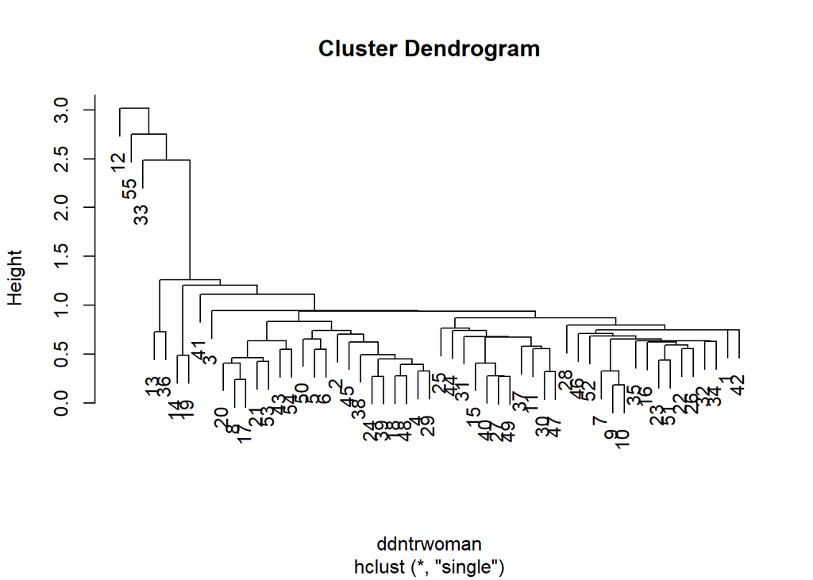

```r
# dengan single linkage
hc2ntrwomen <- hclust(ddntrwoman, method = "single")
plot(hc2ntrwomen)
```

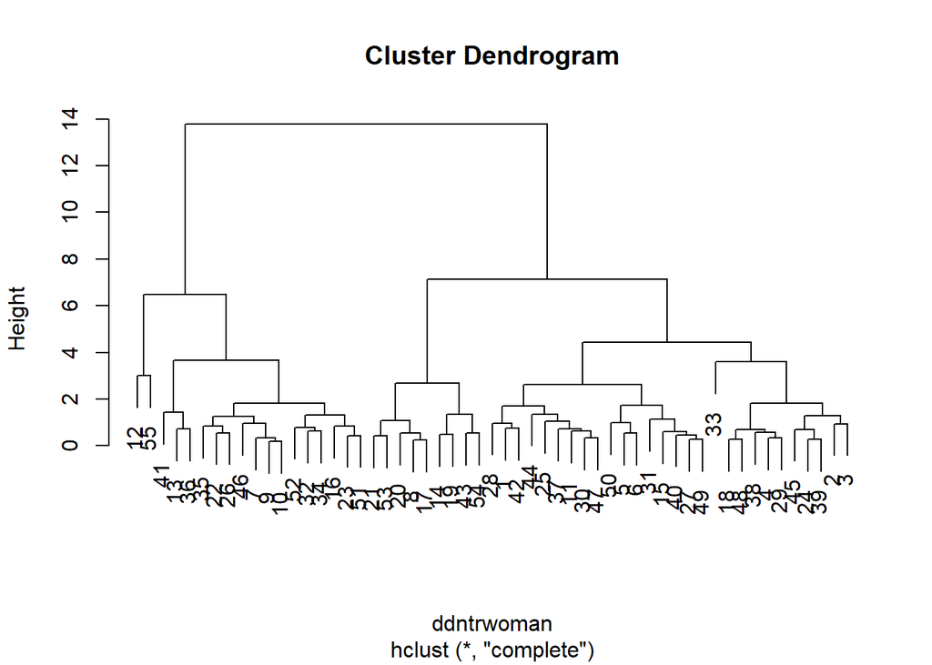

```r
#dengan complete linkage
hc2ntrwomen2 <- hclust(ddntrwoman, method = "complete")
plot(hc2ntrwomen2)
```

3. Input the data in Table 1.9 into a K-means clustering program. Cluster the countries into groups using several values of K. Compare the results with those in Part b.

```r
library(tidyverse)
library(cluster)
library(factoextra)
library(gridExtra)
kmeans2 <- kmeans(mntrwomen, centers = 2, nstart = 25)
kmeans3 <- kmeans(mntrwomen, centers = 3, nstart = 25)
kmeans4 <- kmeans(mntrwomen, centers = 4, nstart = 25)
kmeans5 <- kmeans(mntrwomen, centers = 5, nstart = 25)

str(kmeans2)
```

```
## List of 9
##  $ cluster     : int [1:55] 1 2 2 2 2 2 1 2 1 1 ...
##  $ centers     : num [1:2, 1:6] 12 11.3 24.5 22.9 55.7 ...
##   ..- attr(*, "dimnames")=List of 2
##   .. ..$ : chr [1:2] "1" "2"
##   .. ..$ : chr [1:6] "X100m" "X200m" "X400m" "X800m" ...
##  $ totss       : num 508
##  $ withinss    : num [1:2] 110.3 93.6
##  $ tot.withinss: num 204
##  $ betweenss   : num 304
##  $ size        : int [1:2] 26 29
##  $ iter        : int 1
##  $ ifault      : int 0
##  - attr(*, "class")= chr "kmeans"
```

```r
str(kmeans3) # to see the variables that are used
```

```
## List of 9
##  $ cluster     : int [1:55] 1 2 2 2 1 1 1 2 1 1 ...
##  $ centers     : num [1:3, 1:6] 11.8 11.2 12.3 24 22.7 ...
##   ..- attr(*, "dimnames")=List of 2
##   .. ..$ : chr [1:3] "1" "2" "3"
##   .. ..$ : chr [1:6] "X100m" "X200m" "X400m" "X800m" ...
##  $ totss       : num 508
##  $ withinss    : num [1:3] 54.3 52 16.3
##  $ tot.withinss: num 123
##  $ betweenss   : num 386
##  $ size        : int [1:3] 29 21 5
##  $ iter        : int 2
##  $ ifault      : int 0
##  - attr(*, "class")= chr "kmeans"
```

```r
str(kmeans4)
```

```
## List of 9
##  $ cluster     : int [1:55] 1 4 4 3 3 3 1 4 1 1 ...
##  $ centers     : num [1:4, 1:6] 11.9 12.3 11.5 11.1 24.2 ...
##   ..- attr(*, "dimnames")=List of 2
##   .. ..$ : chr [1:4] "1" "2" "3" "4"
##   .. ..$ : chr [1:6] "X100m" "X200m" "X400m" "X800m" ...
##  $ totss       : num 508
##  $ withinss    : num [1:4] 15.3 16.3 32.3 12.6
##  $ tot.withinss: num 76.5
##  $ betweenss   : num 432
##  $ size        : int [1:4] 17 5 22 11
##  $ iter        : int 2
##  $ ifault      : int 0
##  - attr(*, "class")= chr "kmeans"
```

```r
str(kmeans5)
```

```
## List of 9
##  $ cluster     : int [1:55] 1 2 2 2 1 1 4 5 4 4 ...
##  $ centers     : num [1:5, 1:6] 11.6 11.4 12.3 11.9 11 ...
##   ..- attr(*, "dimnames")=List of 2
##   .. ..$ : chr [1:5] "1" "2" "3" "4" ...
##   .. ..$ : chr [1:6] "X100m" "X200m" "X400m" "X800m" ...
##  $ totss       : num 508
##  $ withinss    : num [1:5] 9.72 14.1 16.26 10.59 8.12
##  $ tot.withinss: num 58.8
##  $ betweenss   : num 450
##  $ size        : int [1:5] 14 12 5 15 9
##  $ iter        : int 2
##  $ ifault      : int 0
##  - attr(*, "class")= chr "kmeans"
```

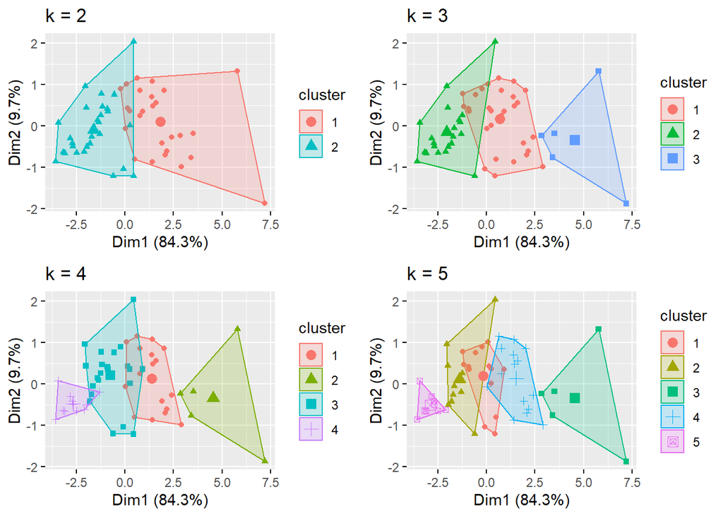

```r
plot1 <- fviz_cluster(kmeans2, geom = "point", data = mntrwomen) +
ggtitle("k = 2")
plot2 <- fviz_cluster(kmeans3, geom = "point", data = mntrwomen) +
ggtitle("k = 3")
plot3 <- fviz_cluster(kmeans4, geom = "point", data = mntrwomen) +
ggtitle("k = 4")
plot4 <- fviz_cluster(kmeans5, geom = "point", data = mntrwomen) +
ggtitle("k = 5")
grid.arrange(plot1, plot2, plot3, plot4, nrow = 2)
```

perbandingan dengan metode hierarchical dengan single linkage dan complete linkage dengan metode k-means. pada metode hierarchical bisa dilihat tingkatan cluster secara detail di banding metode k-means. hal ini masih bisa ditangani karena jumlah observasi yang masih terhitung sedikit untuk metode hierarchical